# Weight Lifting Exercise Dumbell Performance Assignment

cgb

July 8, 2017

## Project Description

Using data from the WLE dataset*,this assignment goal was to determine how well 6 participants performed barbell lifts using accelerometer data on the belt, forearm, arm, and dumbell of the participants. These participants were asked to perform the lifts correctly and incorrectly(in 4 different ways). To accomplish this we were tasked with developing a prediction model that accurately predicts the manner in which the exercises were performed. The outcome was captured as a classe variable. Classe A was performed correctly, classes B,C,D,E were performed incorrectly in one of four ways. After exploring and cleansing the data, and utilizing random forest model method (with k-fold cross-validation of 10 subsets), I obtained a 99.76% accuracy rate(mtry 27) and a oob rate of just .21% which should be close to my out of sample error. Using this model, I was then able to obtain 100% accuracy on the 20 test observation quiz portion of the assignment.

```r
library(randomForest)
library(ElemStatLearn)
library(pgmm)
library(rpart)
library(caret)
library(e1071)
library(rattle)
library(rpart.plot)
```

## Process for Model building

I first needed to download the training and testing data from the har site and read into tables. I then set.seed for reproducibility.

```r
fileurl<-"https://d396qusza40orc.cloudfront.net/predmachlearn/pml-training.csv"
download.file(fileurl,destfile="./pml-training.csv")
training<-read.table("./pml-training.csv",sep="," ,header=TRUE)
fileurl1<-"https://d396qusza40orc.cloudfront.net/predmachlearn/pml-testing.csv"
download.file(fileurl1,destfile="./pml-testing.csv")
testing<-read.table("./pml-testing.csv",sep="," ,header=TRUE)
set.seed(1111)
```

I then performed some exploratory data analysis to see what we had. Understanding that classe was the outcome to be predicted, I reaffirmed the number of unique classes contained in the data, ensured it was a factor variable, and then looked at the other variables noticing many had missing values or NAs. I determined that only a small percentage of rows contained all the data and these were tied to the variable new_window with a value of “yes”. So I removed these rows and then was able to eliminate the variable columns that contained only na or missing values.

```r
class(training$classe)
nsv<-nearZeroVar(training, saveMetrics=TRUE)
nsv
## gave me list of columns that provided me near zero values
##determined when new_window == yes then a value was placed in all of these columns so removed
training2<-training[training$new_window=="no",]
##then removed columns that were filled with na or blank
training4<-training2[!sapply(training2, function (x) all(is.na(x) | x == ""))]
```

[output not shown]

I then decided because of the large number of observations to break the training set into a training and validation set since we would be predicting a test set as part of the quiz, I wanted to be able to test my model first using a validation set.

```r
##create my training and validation sets
inTrain = createDataPartition(training4$classe, p = 3/4)[[1]]
trainingfinal = training4[ inTrain,]
validat = training4[-inTrain,]
```

I then looked at the 60 variables left in the two sets to see if there were more variables I could eliminate.In addition I also checked for missing data with complete.cases. I looked at the cvtd_timestamp to see if there was a time dependency time frame but found none, so I determined I could eliminate all time variables as well as the user name (since they all did the exact same thing) and x. I then eliminated the same variables in the test set but then discovered it had an additional variable called problem_id not found in the original training set and eliminated that as well.

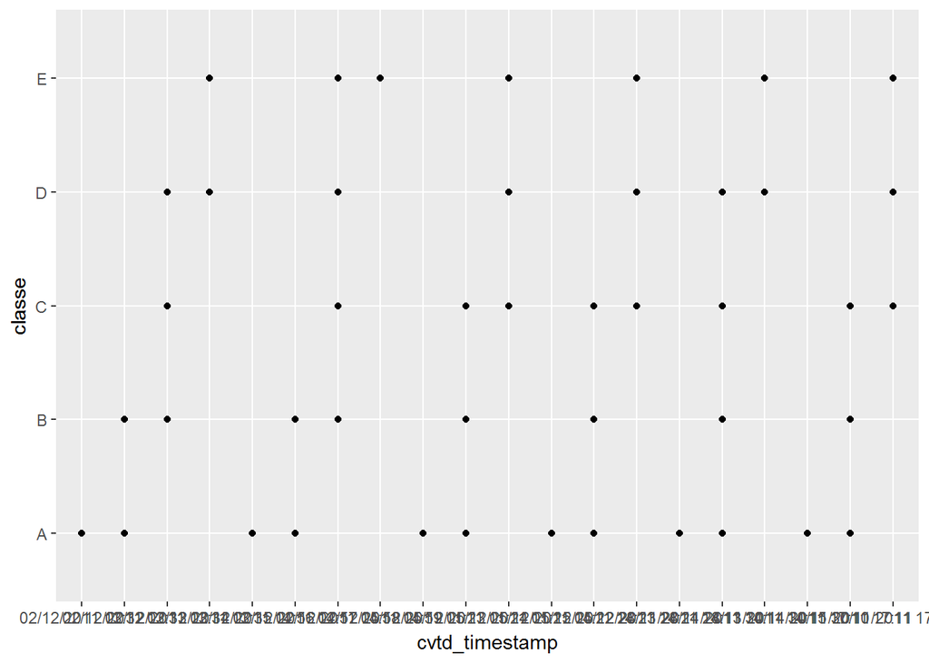

```r
## looked at additional values for inconsequential variables
tm<-unique(trainingfinal$cvtd_timestamp)
tm
qplot(cvtd_timestamp, classe, data=trainingfinal)
```

```r
##doesn't appear time has any impact on outcome so will not use variable
summary(trainingfinal)
##check for missing values
sum(complete.cases(trainingfinal))
##removed inconsequential columns for easier handling
trainingfinal2<-trainingfinal[,-c(1,2,3,4,5,6)]
validatfinal<-validat[,-c(1,2,3,4,5,6)]
##now subset testing data
testingfinal<-testing[!sapply(testing, function (x) all(is.na(x) | x == ""))]
testingfinal2<-testingfinal[,-c(1,2,3,4,5,6,60)]
##remove same variables from testing plus the additional problem id
```

[output not shown]

Because the outcome was a classification and the goal of this assignment was prediction accuracy (and I had a good data set size and a large number of variables) I decided to select random forest as my method to build the model. I used 10 fold cross validation in trainControl as a precaution against overfitting (in addition to the reserved a validation data set).

```r
controlrandom <- trainControl(method="cv", 10)
modfitrf <- train(classe ~ ., data=trainingfinal2, method="rf", trControl=controlrandom, ntree=250)

modfitrf
```

```
## Random Forest
##
## 14414 samples
##    53 predictor
##     5 classes: 'A', 'B', 'C', 'D', 'E'
##
## No pre-processing
## Resampling: Cross-Validated (10 fold)
## Summary of sample sizes: 12972, 12972, 12974, 12973, 12971, 12972, ...
## Resampling results across tuning parameters:
##
##   mtry  Accuracy   Kappa
##    2    0.9946580  0.9932418
##   27    0.9976417  0.9970167
##   53    0.9943813  0.9928915
##
## Accuracy was used to select the optimal model using  the largest value.
## The final value used for the model was mtry = 27.
```

```r
## oob estimate
modfitrf$finalModel
```

```
##
## Call:
##  randomForest(x = x, y = y, ntree = 250, mtry = param$mtry)
##                Type of random forest: classification
##                      Number of trees: 250
## No. of variables tried at each split: 27
##
##         OOB estimate of  error rate: 0.21%
## Confusion matrix:
##      A    B    C    D    E  class.error
## A 4102    2    0    0    0 0.0004873294
## B    9 2779    1    0    0 0.0035855145
## C    0    6 2508    0    0 0.0023866348
## D    0    0    9 2352    0 0.0038119441
## E    0    1    0    2 2643 0.0011337868
```

I then explored which variables were most important.

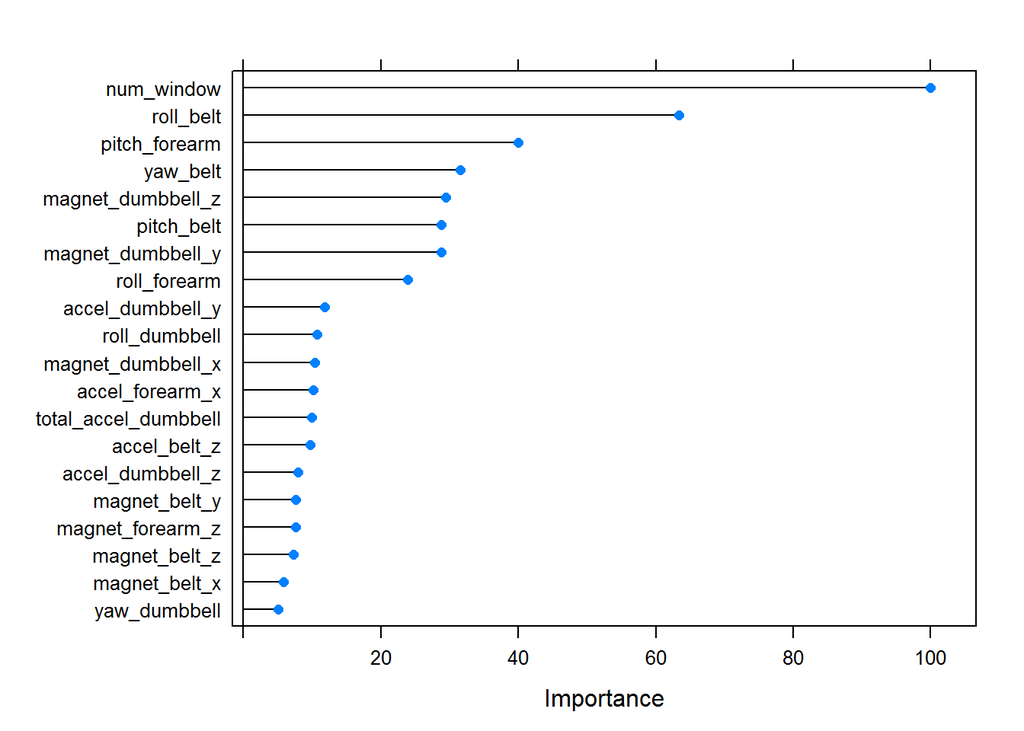

```r
##variable importance
varim <- varImp(modfitrf)
plot(varImp(modfitrf),top=20)
```

I then turned to using my validation set to predict against to check accuracy:

```r
##test on validatfinal to cross validate
predictvalidat <- predict(modfitrf,validatfinal)
confusionMatrix(validatfinal$classe, predictvalidat)
```

```
## Confusion Matrix and Statistics
##
##           Reference
## Prediction    A    B    C    D    E
##          A 1366    0    0    0    1
##          B    2  926    1    0    0
##          C    0    1  837    0    0
##          D    0    0    1  785    0
##          E    0    0    0    1  881
##
## Overall Statistics
##
##                Accuracy : 0.9985
##                  95% CI : (0.997, 0.9994)
##     No Information Rate : 0.2849
##     P-Value [Acc > NIR] : < 2.2e-16
##
##                   Kappa : 0.9982
##  Mcnemar's Test P-Value : NA
##
## Statistics by Class:
##
##                      Class: A Class: B Class: C Class: D Class: E
## Sensitivity            0.9985   0.9989   0.9976   0.9987   0.9989
## Specificity            0.9997   0.9992   0.9997   0.9998   0.9997
## Pos Pred Value         0.9993   0.9968   0.9988   0.9987   0.9989
## Neg Pred Value         0.9994   0.9997   0.9995   0.9998   0.9997
## Prevalence             0.2849   0.1930   0.1747   0.1637   0.1837
## Detection Rate         0.2845   0.1928   0.1743   0.1635   0.1835
## Detection Prevalence   0.2847   0.1935   0.1745   0.1637   0.1837
## Balanced Accuracy      0.9991   0.9991   0.9987   0.9992   0.9993
```

Then I ran on test set:

```r
##now run on test data sample of 20
prediction <- predict(modfitrf, testingfinal2)
```

## Appendix

*Ugulino, W.; Cardador, D.; Vega, K.; Velloso, E.; Milidiu, R.; Fuks, H. Wearable Computing: Accelerometers’ Data Classification of Body Postures and Movements. Proceedings of 21st Brazilian Symposium on Artificial Intelligence. Advances in Artificial Intelligence - SBIA 2012. In: Lecture Notes in Computer Science. , pp. 52-61. Curitiba, PR: Springer Berlin / Heidelberg, 2012. ISBN 978-3-642-34458-9. DOI: 10.1007/978-3-642-34459-6_6. Cited by 2 (Google Scholar)

Read more: http://groupware.les.inf.puc-rio.br/har#ixzz4mFOy9Wwc